# Week 7 lab practice

# General instructions

To answer the questions in this practice sheet:

1. Open `week-7-practice.R` located in the `code/` sub-folder and set the **working directory** to its location. In RStudio,

   ```
   Session > Set Working Directory > To Source File Location
   ```

2. Apply the code you saw in the demonstration scripts and pre-recorded demonstration videos to answer the questions below.

By completing the tasks in this document, **you will practice** with:

- diagnostic tools for model (mis)specificaion;
- diagnostic tools for assumptions related to the residuals;
- computation of robustness standard errors;
- influential observations.

You will need only the following **dataset**:

- `airQual.rds` stored in the `data/` sub-folder

# 1 Preliminaries

## 1.1 - Use the `install.packages` function to install the `moments`, `lmtest`, and `sandwich` packages.

```r
# Install the packages
install.packages(
     pkgs = c("moments", "lmtest", "sandwich"),
     repos = "http://cloud.r-project.org"
)
```

## 1.2 - Use the `library` function to load the `moments`, `lmtest`, and `sandwich` packages.

```r
# Load the packages
library(moments)
library(lmtest)
library(sandwich)
```

## 1.3 - Use the `readRDS` function to load the `airQual.rds` dataset into your workspace.

```r
# Read the data
airQual <- readRDS("../data/airQual.rds")
```

# 2 Model specification

Use the `airQual` data to complete the following:

## 2.1 - Regress `Temp` onto `Ozone`, `Wind`, and `Solar.R`.

**Note**: In the following sections, this model will be referred to as `mod`.

```r
# Fit the requested model
out1 <- lm(Temp ~ Ozone + Wind + Solar.R, data = airQual)

summary(out1)
```

```
Call:
lm(formula = Temp ~ Ozone + Wind + Solar.R, data = airQual)

Residuals:
     Min       1Q   Median       3Q      Max
-19.4279  -5.2861   0.9516   4.7519  18.4852

Coefficients:
             Estimate Std. Error t value Pr(>|t|)
(Intercept) 74.237739   2.637232  28.150  < 2e-16 ***
Ozone        0.154565   0.020668   7.479 5.99e-12 ***
Wind        -0.415996   0.193303  -2.152    0.033 *
Solar.R      0.006881   0.006709   1.026    0.307
---
Signif. codes:  0 '***' 0.001 '**' 0.01 '*' 0.05 '.' 0.1 ' ' 1

Residual standard error: 7.046 on 149 degrees of freedom
Multiple R-squared:  0.4568,    Adjusted R-squared:  0.4458
F-statistic: 41.76 on 3 and 149 DF,  p-value: < 2.2e-16
```

## 2.2 - Plot the residuals from model `mod` against its fitted values.

**Tip**: Remember to include the [loess](https://en.wikipedia.org/wiki/Local_regression) line and a horizontal line at 0, the assumed mean value of the errors. These will help you read the plot.

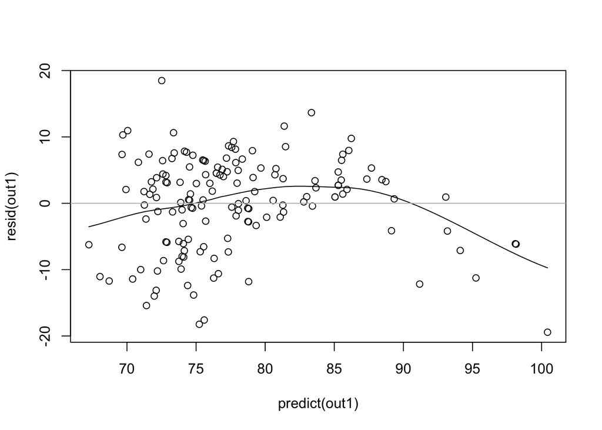

```r
# Plot the loess line
scatter.smooth(x = predict(out1), y = resid(out1))

# Add a horizontal line at 0, the assumed mean for the errors
abline(h = 0, col = "gray")
```

## 2.3 - What can you infer from the plot created in 2.2?

The model appears to be grossly misspecified.

## 2.4 - What do you think is the best course of action to correct the issue identified in 2.3?

We probably need to include some non-linear terms.

## 2.5 - Conduct a Ramsey Regression Equation Specification Error Test (RESET) for the model estimated in 2.1.

**Note**: Make sure you are testing for both quadratic and cubic terms.

```r
# Perform Ramsey reset with defaults
resettest(out1)
```

```
    RESET test

data:  out1
RESET = 16.13, df1 = 2, df2 = 147, p-value = 4.643e-07
```

## 2.6 - What do the results of the RESET tell you?

The model is misspecified.

## 2.7 - Update the model `mod` with squared terms.

Estimate three new models. Each of these three models should be identical to `mod`, the model estimated in 2.1, except for the inclusion of a different quadratic term.

```r
# Define the predictors that should use the additional squared term
vars <- c("Solar.R", "Ozone", "Wind")

# Update the baseline model with the squared terms
fits <- lapply(
     X = vars,
     FUN = function(x, base) {
          update(base, paste0(". ~ . + I(", x, "^2)"))
     },
     base = out1
)

# Give meaningful names to the new list of fits
names(fits) <- vars

# Apply the summary function to each fit object
lapply(fits, summary)
```

```
$Solar.R

Call:
lm(formula = Temp ~ Ozone + Wind + Solar.R + I(Solar.R^2), data = airQual)

Residuals:
    Min      1Q  Median      3Q     Max
-19.346  -4.337   1.136   4.699  19.015

Coefficients:
               Estimate Std. Error t value Pr(>|t|)
(Intercept)   7.044e+01  3.137e+00  22.453  < 2e-16 ***
Ozone         1.442e-01  2.096e-02   6.880 1.57e-10 ***
Wind         -3.644e-01  1.924e-01  -1.894   0.0602 .
Solar.R       6.712e-02  2.848e-02   2.357   0.0198 *
I(Solar.R^2) -1.755e-04  8.071e-05  -2.175   0.0312 *
---
Signif. codes:  0 '***' 0.001 '**' 0.01 '*' 0.05 '.' 0.1 ' ' 1

Residual standard error: 6.96 on 148 degrees of freedom
Multiple R-squared:  0.4736,    Adjusted R-squared:  0.4594
F-statistic: 33.29 on 4 and 148 DF,  p-value: < 2.2e-16


$Ozone

Call:
lm(formula = Temp ~ Ozone + Wind + Solar.R + I(Ozone^2), data = airQual)

Residuals:
     Min       1Q   Median       3Q      Max
-19.8326  -3.4969   0.7958   4.2054  19.9494

Coefficients:
              Estimate Std. Error t value Pr(>|t|)
(Intercept) 67.0063682  2.7679235  24.208  < 2e-16 ***
Ozone        0.4170463  0.0523294   7.970 3.93e-13 ***
Wind        -0.1553622  0.1838663  -0.845    0.399
Solar.R      0.0004747  0.0062699   0.076    0.940
I(Ozone^2)  -0.0017647  0.0003279  -5.382 2.83e-07 ***
```

[output cut: 15 more lines]

```
-18.257  -4.864   1.319   4.669  18.918

Coefficients:
             Estimate Std. Error t value Pr(>|t|)
(Intercept) 68.862956   4.593636  14.991  < 2e-16 ***
Ozone        0.162895   0.021408   7.609 2.98e-12 ***
Wind         0.659176   0.777891   0.847    0.398
Solar.R      0.005679   0.006738   0.843    0.401
I(Wind^2)   -0.048925   0.034295  -1.427    0.156
---
Signif. codes:  0 '***' 0.001 '**' 0.01 '*' 0.05 '.' 0.1 ' ' 1

Residual standard error: 7.022 on 148 degrees of freedom
Multiple R-squared:  0.4642,    Adjusted R-squared:  0.4497
F-statistic: 32.05 on 4 and 148 DF,  p-value: < 2.2e-16
```

## 2.8 - Plot the residuals from each of the updated models estimated in 2.7 against their fitted values.

**Tip**: Use the same functions you used in 2.2.

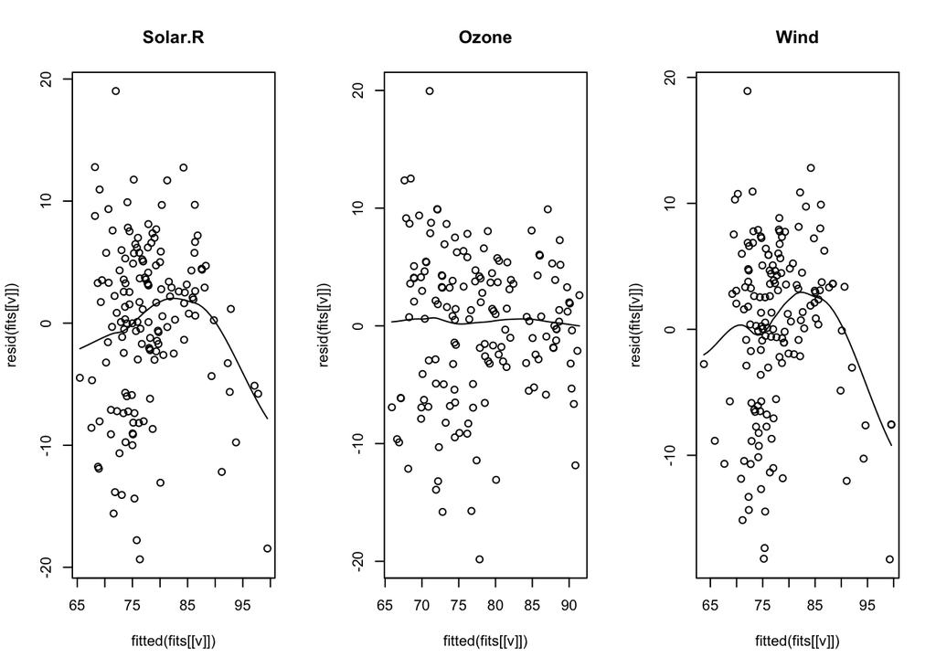

```r
# Define a plot device with 1 row and three columns
par(mfrow = c(1, 3))

# Obtain the loess residual plot for every fitted model
for (v in vars) {
     scatter.smooth(
          x = fitted(fits[[v]]),   # fitted values of interest
          y = resid(fits[[v]]),    # residuals of interest
          main = v                 # title
     )
}
```

## 2.9 - Conduct a RESET for each of the updated models estimated in 2.7.

```r
# Apply the Ramsey reset test to each new model
reset <- lapply(fits, resettest)

# Look at the results
reset
```

```
$Solar.R

    RESET test

data:  X[[i]]
RESET = 12.868, df1 = 2, df2 = 146, p-value = 7.124e-06


$Ozone

    RESET test

data:  X[[i]]
RESET = 0.078466, df1 = 2, df2 = 146, p-value = 0.9246


$Wind

    RESET test

data:  X[[i]]
RESET = 15.225, df1 = 2, df2 = 146, p-value = 9.872e-07
```

## 2.10 - Which predictor’s quadratic term most improved the model specification?

```r
# Extract the model with the smallest Ramsey reset test statistic
best <- which.min(sapply(reset, "[[", x = "statistic"))

# Print the name of the associated model
names(reset)[best]
```

```
[1] "Ozone"
```

## 2.11 - Does the RESET for the model you indicated in 2.10 still suggest significant misspecification?

```r
# Is the p-value below 0.05?
check <- reset[[best]]$p.value < 0.05

# Then, the answer is...
ifelse(check, "YES", "NO")
```

```
[1] "NO"
```

## 2.12 - Do the plots obtained form 2.8 agree with the conclusion from 2.11?

Yes. The plot for `Ozone` shows a flat loess line, which does not suggest misspecification.

# 3 Diagnostics

Use the `airQual` data to complete the following:

## 3.1 - Regress `Temp` onto `Ozone`, `Wind`, `Solar.R`, and the square of `Ozone`.

**Note**: In the following sections, this model will be referred to as `modO2`.

```r
# Fit linear model
modO2 <- lm(Temp ~ Ozone + Wind + Solar.R + I(Ozone^2), data = airQual)
```

## 3.2 - Plot the residuals from model `mod02` against its fitted values.

**Note**: Make sure to have the loess line in the plot.

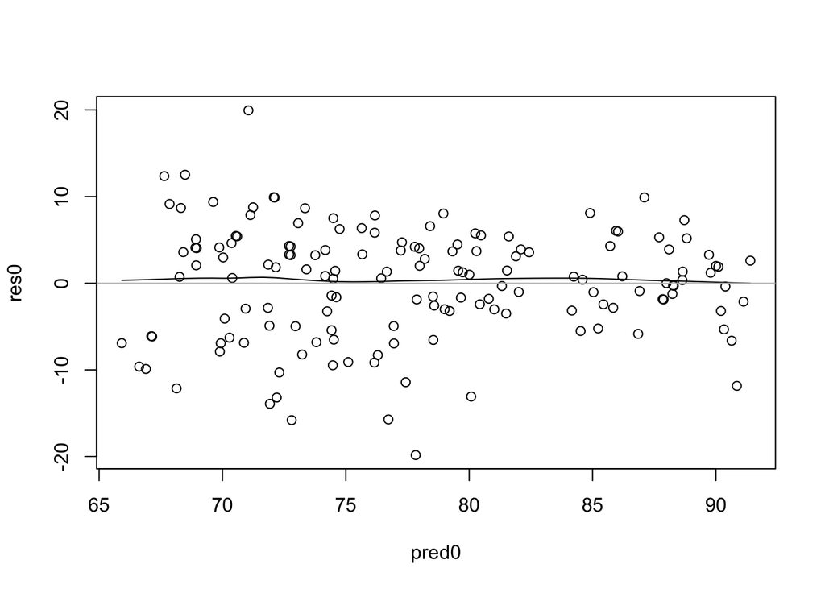

```r
# Extract the residuals
res0 <- resid(modO2)

# Extract the predicted values
pred0 <- predict(modO2)

# Plot the residual plot with the loess line
scatter.smooth(x = pred0, y = res0)

# Add reference horizontal line
abline(h = 0, col = "gray")
```

## 3.3 - What can you infer from the plot created in 3.2?

The model does not appear to be misspecified, but there may be some heteroscedasticity.

## 3.4 - Conduct a Breusch-Pagan test for model `modO2`.

```r
# Conduct Breusch-Pagan test
bptest(modO2)
```

```
    studentized Breusch-Pagan test

data:  modO2
BP = 16.285, df = 4, p-value = 0.002659
```

## 3.5 - What does the Breusch-Pagan test tell you about the residuals in `modO2`?

The hypothesis of homoscedasticity is rejected, so the errors are non-constant.

## 3.6 - Is the Breusch-Pagan test in agreement with the residual plots from 3.2?

Yes. Both tools suggest the violation of homoscedastic errors.

## 3.7 - Evaluate the normality of the residuals from model `modO2`

To answer this question, make sure to use the following diagnostic tools:

- Q-Q plot;
- Plot the kernel density of the residuals;
- skewness;
- kurtosis;
- Shapiro-Wilk test;
- the Kolmogorov-Smirnov test.

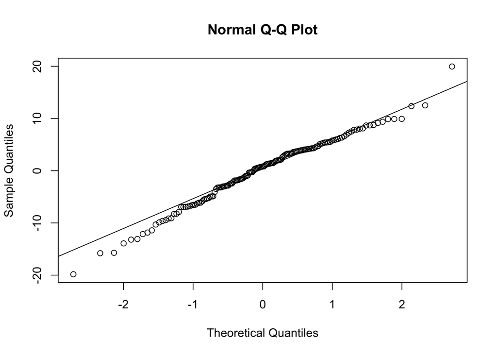

```r
# Obtain QQ plots
qqnorm(res0)
qqline(res0)
```

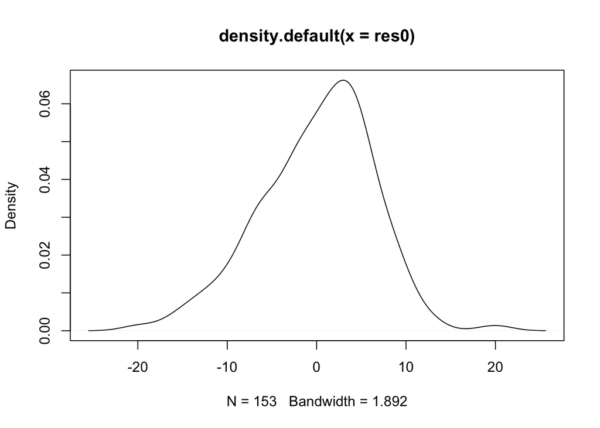

```r
# Plot the density of the residuals
plot(density(res0))
```

```r
# Compute skewness and kurtosis
skewness(res0)
```

```
[1] -0.3525046
```

```r
kurtosis(res0)
```

```
[1] 3.360761
```

```r
# Perform tests to check non-normality
shapiro.test(res0)
```

```
    Shapiro-Wilk normality test

data:  res0
W = 0.98408, p-value = 0.07536
```

```r
ks.test(x = res0, y = pnorm, mean = mean(res0), sd = sd(res0))
```

```
    Asymptotic one-sample Kolmogorov-Smirnov test

data:  res0
D = 0.071601, p-value = 0.4128
alternative hypothesis: two-sided
```

## 3.8 - Do the results of the diagnostics you conducted in 3.7 agree?

Yes. None of the diagnostic tools we used seems to point to non-normality of the errors.

## 3.9 - Do you think it’s safe to assume normally distributed errors for model `modO2`?

Yes. The errors are likely to be normally distributed, although, based on 3.6, they seem to have non-constant variance.

# 4 Robust SEs

Use the `airQual` data to complete the following:

## 4.1 - Estimate the heteroscedasticity consistent (HC) asymptotic covariance matrix for `modO2`.

```r
# Heteroscedastic estiamtes of covariance matrix for modO2
covHC0 <- vcovHC(modO2)
```

## 4.2 - Use the HC covariance matrix from 4.1 to test the coefficients of `modO2`.

```r
# Use the heteroscedastic estimate to test significance
coeftest(modO2, vcov = covHC0)
```

```
t test of coefficients:

               Estimate  Std. Error t value  Pr(>|t|)
(Intercept) 67.00636819  2.81596039 23.7952 < 2.2e-16 ***
Ozone        0.41704632  0.05280060  7.8985 5.881e-13 ***
Wind        -0.15536217  0.20093936 -0.7732    0.4406
Solar.R      0.00047468  0.00709783  0.0669    0.9468
I(Ozone^2)  -0.00176471  0.00035011 -5.0405 1.337e-06 ***
---
Signif. codes:  0 '***' 0.001 '**' 0.01 '*' 0.05 '.' 0.1 ' ' 1
```

## 4.3 - What changes when using robust SEs?

Compare the results from 4.2 to the default tests for `modO2` coefficients.

```r
# Check out the results from the original model
summary(modO2)$coefficients
```

```
                 Estimate   Std. Error     t value     Pr(>|t|)
(Intercept) 67.0063681934 2.7679235454 24.20817161 2.515041e-53
Ozone        0.4170463210 0.0523293835  7.96963949 3.934582e-13
Wind        -0.1553621741 0.1838662869 -0.84497369 3.994894e-01
Solar.R      0.0004746802 0.0062698827  0.07570799 9.397537e-01
I(Ozone^2)  -0.0017647074 0.0003279018 -5.38181723 2.826568e-07
```

The estimates are unchanged, but the standard errors are different! As a results, test statistics and p-values are also different.

## 4.4 - Update `modO2` by adding the squares of `Wind` and `Solar.R`.

```r
# Update current model with requested terms
modO2.2 <- update(modO2, ". ~ . + I(Wind^2) + I(Solar.R^2)")

# Print the summary
summary(modO2.2)
```

```
Call:
lm(formula = Temp ~ Ozone + Wind + Solar.R + I(Ozone^2) + I(Wind^2) +
    I(Solar.R^2), data = airQual)

Residuals:
     Min       1Q   Median       3Q      Max
-19.5863  -3.4866   0.6477   4.0640  20.5155

Coefficients:
               Estimate Std. Error t value Pr(>|t|)
(Intercept)   6.056e+01  4.554e+00  13.299  < 2e-16 ***
Ozone         4.110e-01  5.558e-02   7.394 1.02e-11 ***
Wind          9.204e-01  7.164e-01   1.285    0.201
Solar.R       2.169e-02  2.776e-02   0.781    0.436
I(Ozone^2)   -1.694e-03  3.389e-04  -4.998 1.63e-06 ***
I(Wind^2)    -4.856e-02  3.153e-02  -1.540    0.126
I(Solar.R^2) -6.453e-05  7.766e-05  -0.831    0.407
---
Signif. codes:  0 '***' 0.001 '**' 0.01 '*' 0.05 '.' 0.1 ' ' 1

Residual standard error: 6.438 on 146 degrees of freedom
Multiple R-squared:  0.5556,    Adjusted R-squared:  0.5374
F-statistic: 30.43 on 6 and 146 DF,  p-value: < 2.2e-16
```

## 4.5 - Does adding the square terms of `Wind` and `Solar.R` to `modO2` explains significantly more variance in `Temp`?

**Tip**: Use the HC estimates of the SEs!

```r
# Use the waldtest functoin to perform change in R-squared test
waldtest(modO2, modO2.2, vcov = vcovHC)
```

```
Wald test

Model 1: Temp ~ Ozone + Wind + Solar.R + I(Ozone^2)
Model 2: Temp ~ Ozone + Wind + Solar.R + I(Ozone^2) + I(Wind^2) + I(Solar.R^2)
  Res.Df Df      F  Pr(>F)
1    148
2    146  2 2.8622 0.06036 .
---
Signif. codes:  0 '***' 0.001 '**' 0.01 '*' 0.05 '.' 0.1 ' ' 1
```

## 4.6 - What is the conclusion of the test you conducted in 4.5?

Adding the two new terms does not explain a significantly greater proportino of variability in `Temp`.

## 4.7 - What differs when using robust SEs?

Compare the test in 4.5 to the default change in R-squared test that does not use HC estimates of the SEs.

```r
# Use the traditional anova function to perform a change in R-squared test
anova(modO2, modO2.2)
```

```
Analysis of Variance Table

Model 1: Temp ~ Ozone + Wind + Solar.R + I(Ozone^2)
Model 2: Temp ~ Ozone + Wind + Solar.R + I(Ozone^2) + I(Wind^2) + I(Solar.R^2)
  Res.Df    RSS Df Sum of Sq     F Pr(>F)
1    148 6186.7
2    146 6051.4  2    135.29 1.632 0.1991
```

The robust version produces a larger F (test) statistic, resulting in a smaller p-value, compared to the standard approach that assumes homoscedasticity.

# 5 Influential observations

Use the `airQual` data to complete the following:

## 5.1 - Compute and obtain the index plot of the studentized residuals of the model `modO2`.

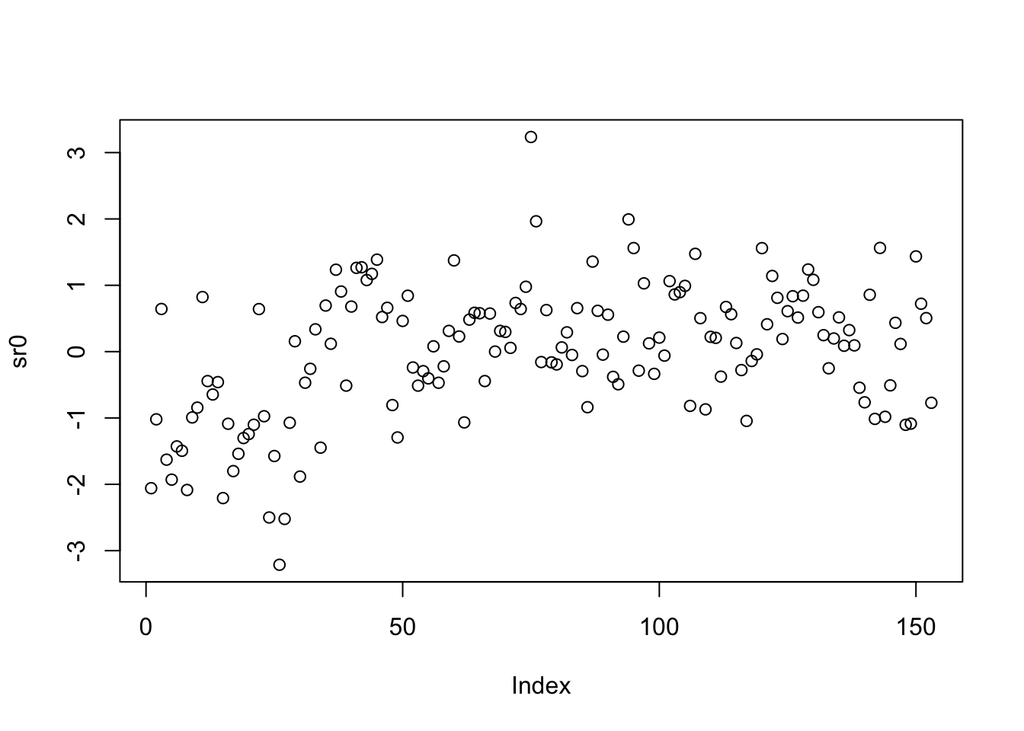

```r
# Compute the studentized residuals
sr0 <- rstudent(modO2)

# Compute an index plot of the residuals
plot(sr0)
```

## 5.2 - What can you infer from the plot in 5.1?

Two observations appear to be potential outliers (studentized residuals larger than 3.)

## 5.3 - What are the observation numbers for the two most probable outliers according to the residuals from 5.1?

To answer this question (and some following ones) it can be helpful to define a function to identify the n biggest values in a vector.

```r
# Define function to find names of elements with biggest values
findBiggest <- function(x, n) {
     as.numeric(names(sort(abs(x), decreasing = TRUE)[1:n]))
}

# Use function to find names of biggest elements
badSr <- findBiggest(sr0, 2)

# Print results
badSr
```

```
[1] 75 26
```

## 5.4 - Compute and obtain the index plot of the leverages of the model `modO2`.

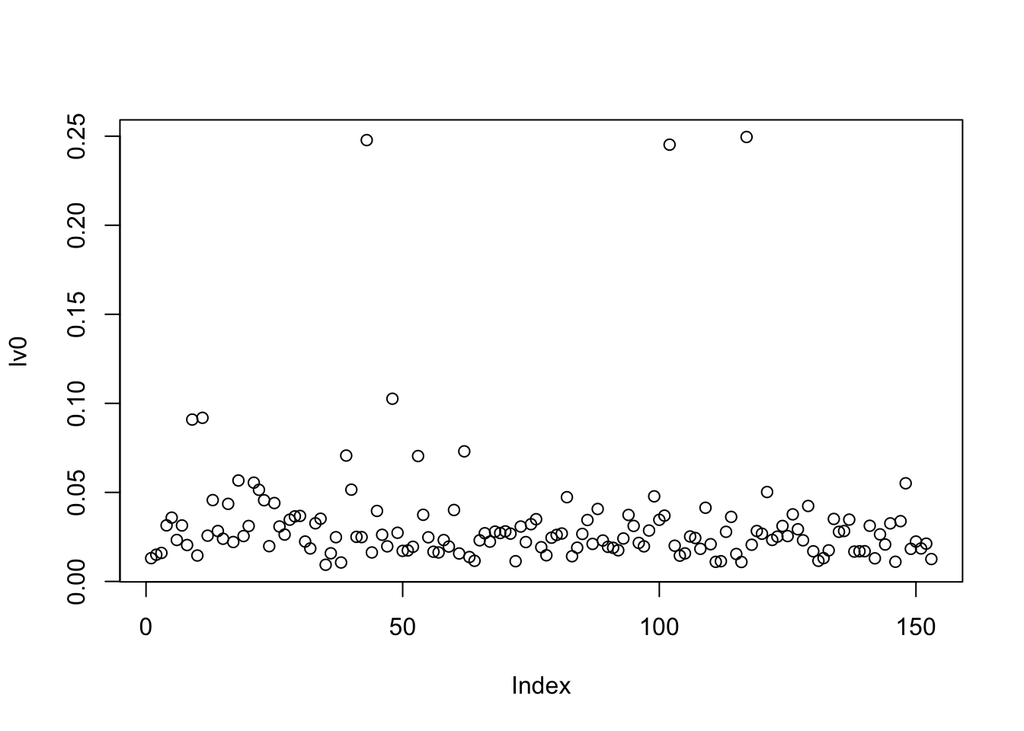

```r
# Compute leverages (or hat values)
lv0 <- hatvalues(modO2)

# Plot leverages
plot(lv0)
```

## 5.5 - What can you infer from the plot in 5.4?

Three observations seem to have especially high leverages.

## 5.6 - What are the observation numbers with the three highest leverages?

```r
# Find biggest 3 leverages
badLv <- findBiggest(lv0, 3)

# And check out the results
badLv
```

```
[1] 117  43 102
```

## 5.7 - Compute and obtain the index plot of the Cook’s distances of the model `modO2`.

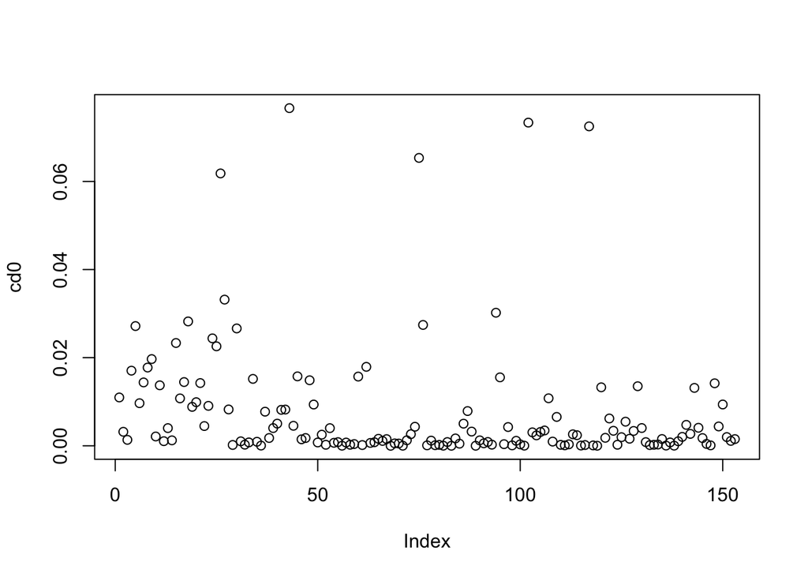

```r
# Compute cook's distances
cd0 <- cooks.distance(modO2)

# Plot cook's distances
plot(cd0)
```

## 5.8 - What can you infer from the plot in 5.7?

Five observations appear to be especially influential.

## 5.9 - What are the observation numbers for the five most influential cases according to the Cook’s distances?

```r
# Find the names of the 5 observations with biggest cook distances
badCd <- findBiggest(cd0, 5)

# Print results
badCd
```

```
[1]  43 102 117  75  26
```

## 5.10 - Compute and obtain the index plot of the DFFITS of the model `modO2`.

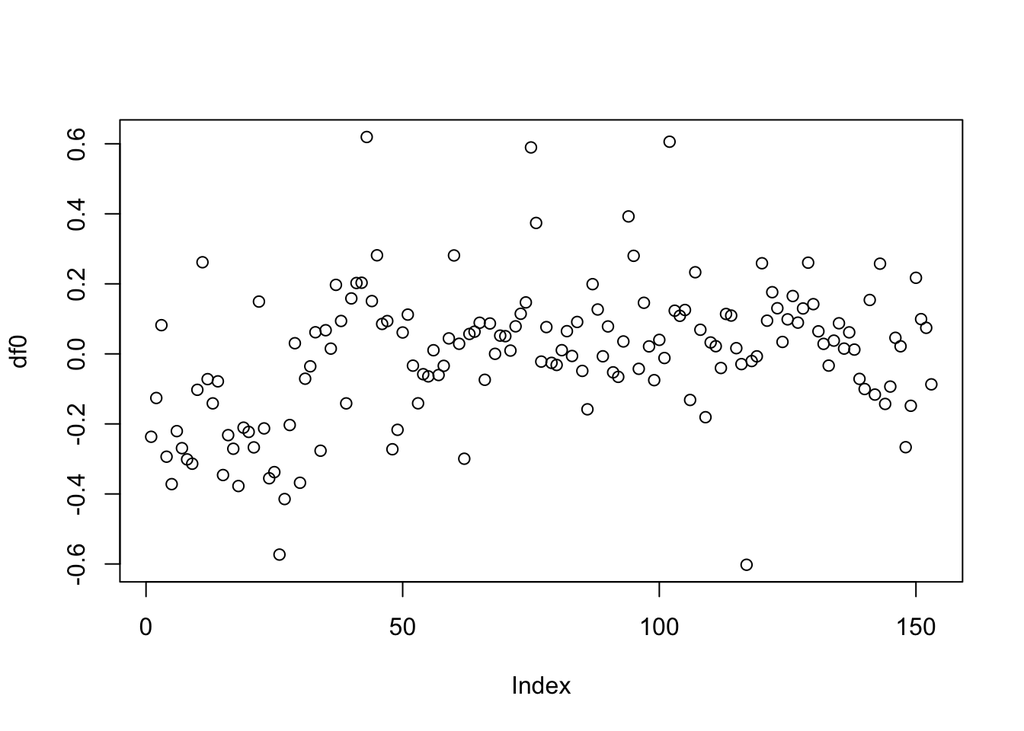

```r
# Compute differences in fits
df0 <- dffits(modO2)

# Plot results
plot(df0)
```

## 5.11 - What can you infer from the plot in 5.10?

Five cases appear to be potentially influential.

## 5.12 - What are the observation numbers for the five most influential cases according to the DFFITS?

```r
# Find the names of the 5 observations with biggest DFFITS
badDf <- findBiggest(abs(df0), 5)

# Print results
badDf
```

```
[1]  43 102 117  75  26
```

## 5.13 - Do the results from 5.12 agree with the results from 5.9?

```r
# Check whether the observations are the same
check <- all.equal(sort(badDf), sort(badCd))

# And return a clear answer
ifelse(check, "YES", "NO")
```

```
[1] "YES"
```

## 5.14 - What do you notice about the set of observations flagged as influential cases in 5.12 relative to the observations flagged as high leverage points in 5.6 and those flagged as outliers in 5.3?

```r
# Print the names of the observations flagged
badSr
```

```
[1] 75 26
```

```r
badLv
```

```
[1] 117  43 102
```

```r
badDf
```

```
[1]  43 102 117  75  26
```

All fo the high-leverage cases and all of the outliers were flagged as influential.

## 5.15 - Remove the five most influential cases from 5.12, and use the cleaned data to rerun `modO2`.

```r
# Re-estimate the model without flagged observations
modO2.3 <- update(modO2, data = airQual[-badDf, ])

# And check out the summary
summary(modO2.3)
```

```
Call:
lm(formula = Temp ~ Ozone + Wind + Solar.R + I(Ozone^2), data = airQual[-badDf,
    ])

Residuals:
     Min       1Q   Median       3Q      Max
-16.1260  -3.6750   0.7825   4.1143  12.9739

Coefficients:
              Estimate Std. Error t value Pr(>|t|)
(Intercept) 66.2186302  2.6687190  24.813  < 2e-16 ***
Ozone        0.4814885  0.0613192   7.852 8.82e-13 ***
Wind        -0.1676699  0.1757024  -0.954    0.342
Solar.R     -0.0009098  0.0059186  -0.154    0.878
I(Ozone^2)  -0.0023481  0.0004807  -4.885 2.73e-06 ***
---
Signif. codes:  0 '***' 0.001 '**' 0.01 '*' 0.05 '.' 0.1 ' ' 1

Residual standard error: 6.049 on 143 degrees of freedom
Multiple R-squared:  0.586, Adjusted R-squared:  0.5745
F-statistic: 50.61 on 4 and 143 DF,  p-value: < 2.2e-16
```

## 5.16 - What changes when removing the influential cases?

**Tip**: Look at the summaries for `mod02` and the model estimated without the most influencial observations.

```r
# Print the results from the original model
summary(modO2)
```

```
Call:
lm(formula = Temp ~ Ozone + Wind + Solar.R + I(Ozone^2), data = airQual)

Residuals:
     Min       1Q   Median       3Q      Max
-19.8326  -3.4969   0.7958   4.2054  19.9494

Coefficients:
              Estimate Std. Error t value Pr(>|t|)
(Intercept) 67.0063682  2.7679235  24.208  < 2e-16 ***
Ozone        0.4170463  0.0523294   7.970 3.93e-13 ***
Wind        -0.1553622  0.1838663  -0.845    0.399
Solar.R      0.0004747  0.0062699   0.076    0.940
I(Ozone^2)  -0.0017647  0.0003279  -5.382 2.83e-07 ***
---
Signif. codes:  0 '***' 0.001 '**' 0.01 '*' 0.05 '.' 0.1 ' ' 1

Residual standard error: 6.465 on 148 degrees of freedom
Multiple R-squared:  0.5457,    Adjusted R-squared:  0.5334
F-statistic: 44.44 on 4 and 148 DF,  p-value: < 2.2e-16
```

The R-squared and the slopes are larger in the model estimated without using the flagged observations.

# 6 TL;DR, just give me the code!

You can paste the following code in your `week-7-practice.R` and run it to obtain the solutions shown here.

```r
# Install the packages
install.packages(
     pkgs = c("moments", "lmtest", "sandwich"),
     repos = "http://cloud.r-project.org"
)

# Load the packages
library(moments)
library(lmtest)
library(sandwich)

# Read the data
airQual <- readRDS("../data/airQual.rds")

# Fit the requested model
out1 <- lm(Temp ~ Ozone + Wind + Solar.R, data = airQual)

summary(out1)

# Plot the loess line
scatter.smooth(x = predict(out1), y = resid(out1))

# Add a horizontal line at 0, the assumed mean for the errors
abline(h = 0, col = "gray")

# Perform Ramsey reset with defaults
resettest(out1)

print.response("The model is misspecified.")

# Define the predictors that should use the additional squared term
vars <- c("Solar.R", "Ozone", "Wind")

# Update the baseline model with the squared terms
fits <- lapply(
     X = vars,
     FUN = function(x, base) {
          update(base, paste0(". ~ . + I(", x, "^2)"))
     },
     base = out1
)

# Give meaningful names to the new list of fits
names(fits) <- vars

# Apply the summary function to each fit object
lapply(fits, summary)

# Define a plot device with 1 row and three columns
par(mfrow = c(1, 3))

# Obtain the loess residual plot for every fitted model
for (v in vars) {
     scatter.smooth(
          x = fitted(fits[[v]]),   # fitted values of interest
          y = resid(fits[[v]]),    # residuals of interest
          main = v                 # title
     )
}

# Apply the Ramsey reset test to each new model
reset <- lapply(fits, resettest)

# Look at the results
reset

# Extract the model with the smallest Ramsey reset test statistic
best <- which.min(sapply(reset, "[[", x = "statistic"))

# Print the name of the associated model
names(reset)[best]

# Is the p-value below 0.05?
check <- reset[[best]]$p.value < 0.05

# Then, the answer is...
ifelse(check, "YES", "NO")

# Fit linear model
modO2 <- lm(Temp ~ Ozone + Wind + Solar.R + I(Ozone^2), data = airQual)

# Extract the residuals
res0 <- resid(modO2)

# Extract the predicted values
pred0 <- predict(modO2)

# Plot the residual plot with the loess line
scatter.smooth(x = pred0, y = res0)

# Add reference horizontal line
abline(h = 0, col = "gray")

# Conduct Breusch-Pagan test
bptest(modO2)

# Obtain QQ plots
qqnorm(res0)
qqline(res0)

# Plot the density of the residuals
plot(density(res0))

# Compute skewness and kurtosis
skewness(res0)
kurtosis(res0)

# Perform tests to check non-normality
shapiro.test(res0)
ks.test(x = res0, y = pnorm, mean = mean(res0), sd = sd(res0))

# Heteroscedastic estiamtes of covariance matrix for modO2
covHC0 <- vcovHC(modO2)

# Use the heteroscedastic estimate to test significance
coeftest(modO2, vcov = covHC0)

# Check out the results from the original model
summary(modO2)$coefficients

# Update current model with requested terms
modO2.2 <- update(modO2, ". ~ . + I(Wind^2) + I(Solar.R^2)")

# Print the summary
summary(modO2.2)

# Use the waldtest functoin to perform change in R-squared test
waldtest(modO2, modO2.2, vcov = vcovHC)

# Use the traditional anova function to perform a change in R-squared test
anova(modO2, modO2.2)

print.response("The robust version produces a larger F (test) statistic, resulting in a smaller p-value, compared to the standard approach that assumes homoscedasticity.")
# Compute the studentized residuals
sr0 <- rstudent(modO2)

# Compute an index plot of the residuals
plot(sr0)

# Define function to find names of elements with biggest values
findBiggest <- function(x, n) {
     as.numeric(names(sort(abs(x), decreasing = TRUE)[1:n]))
}

# Use function to find names of biggest elements
badSr <- findBiggest(sr0, 2)

# Print results
badSr

# Compute leverages (or hat values)
lv0 <- hatvalues(modO2)

# Plot leverages
plot(lv0)

# Find biggest 3 leverages
badLv <- findBiggest(lv0, 3)

# And check out the results
badLv

# Compute cook's distances
cd0 <- cooks.distance(modO2)

# Plot cook's distances
plot(cd0)

# Find the names of the 5 observations with biggest cook distances
badCd <- findBiggest(cd0, 5)

# Print results
badCd

# Compute differences in fits
df0 <- dffits(modO2)

# Plot results
plot(df0)

print.response("Five cases appear to be potentially influential.")
# Find the names of the 5 observations with biggest DFFITS
badDf <- findBiggest(abs(df0), 5)

# Print results
badDf

# Check whether the observations are the same
check <- all.equal(sort(badDf), sort(badCd))

# And return a clear answer
ifelse(check, "YES", "NO")

# Print the names of the observations flagged
badSr
badLv
badDf

# Re-estimate the model without flagged observations
modO2.3 <- update(modO2, data = airQual[-badDf, ])

# And check out the summary
summary(modO2.3)

# Print the results from the original model
summary(modO2)
```